# 分布的集中趨勢、離散程度與標準誤

Week 04 Part 2  
回到 Week 04 Index

HT3001B 生物統計學與 R

2026-10-01

## 中心與長尾：右偏

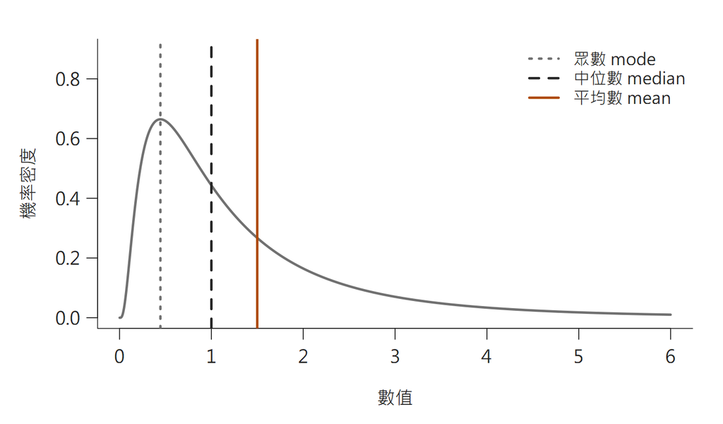

對數常態單峰模型，眾數在左、中位數居中、平均數較靠右側長尾。

集中趨勢（central tendency）：眾數（mode）、中位數（median）、平均數（mean）。

本課程自製模型示意；右偏分配（right-skewed distribution）；IMS §5.2–5.6

## 中心與長尾：左偏

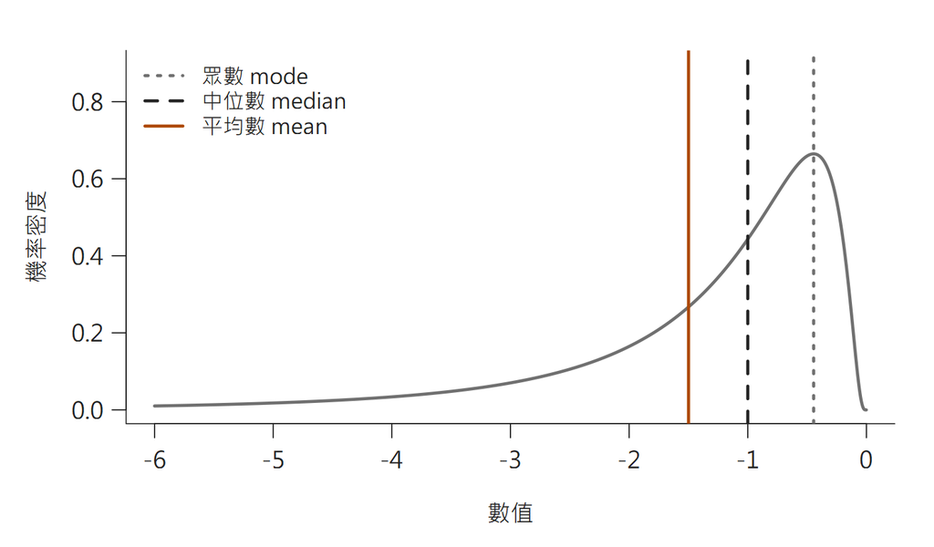

反射對數常態單峰模型，平均數較靠左側長尾，中位數居中、眾數在右。

左偏分配（left-skewed distribution）：圖中平均數較靠左側長尾。

本課程自製模型示意；此位置次序不是所有偏態的通則

## 對稱單峰的中心

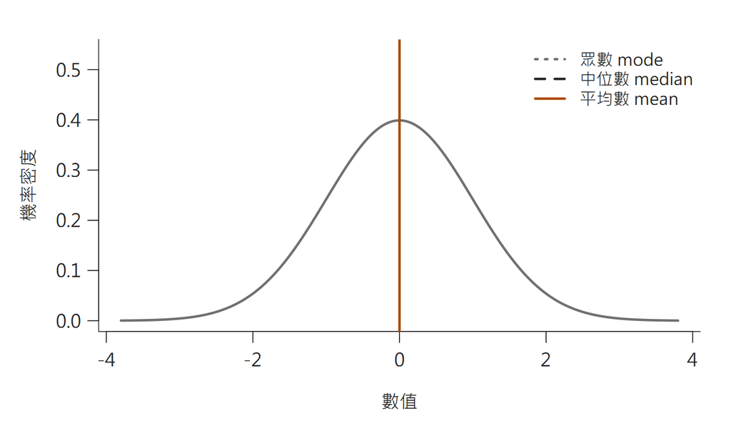

標準常態模型中，平均數、中位數、眾數位於零並重合。

這個模型中三者重合。對稱分配（symmetric distribution）不一定是常態分配（normal distribution）。

本課程自製模型示意；標準常態模型；IMS §5.3

## 平均數：保留總和，平均分配

讓每筆都成為同一數值 $m$：

$$nm=\sum_{i=1}^{n}x_i$$

$$m=\frac{1}{n}\sum_{i=1}^{n}x_i=\bar{x}$$

| 課本貸款利率 | 數值 |
| --- | --- |
| 筆數 $n$ | 50 |
| 利率數值總和 | 578.36 |
| 平均利率 | 11.5672% |

$50m=578.36$，所以 $m=11.5672$。

IMS §5.2、Table 5.3；本課程等量分配推導；依 loan50 原值重算，非本金加權

## 平均數：正負離差恰好抵銷

平均數公式使 $\sum x_i=n\bar{x}$。

$$\begin{aligned}
\sum_{i=1}^{n}(x_i-\bar{x})
&=\sum_{i=1}^{n}x_i-n\bar{x}\\
&=n\bar{x}-n\bar{x}=0.
\end{aligned}$$

**離差和為零，不代表每個離差都是零。**

平均數定義依 IMS §5.2；本課程補充代數推導

## 貸款利率：每點是一筆貸款

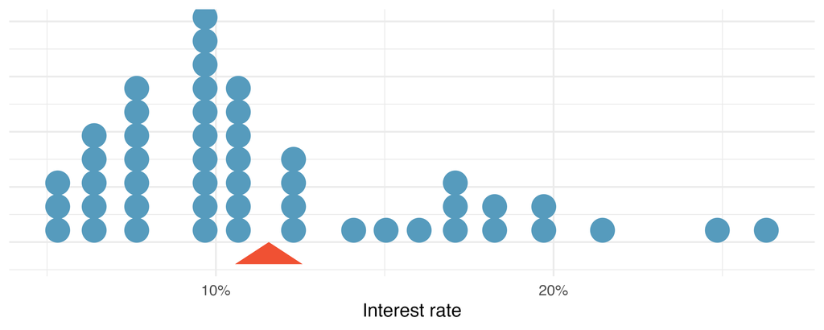

課本50筆利率點圖，作圖時四捨五入至整數百分比，三角形標示均值。

`loan50` 有 50 筆貸款，平均利率為 11.57%。

[IMS 2e](https://openintrostat.github.io/ims/explore-numerical.html) §5.2；Figure 5.3；作圖值取整數百分比

## 中位數：排序後的中央位置

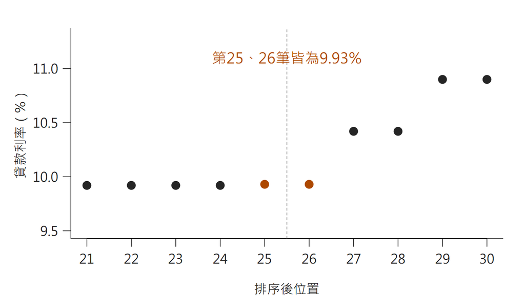

課本排序資料第21至30筆節錄，第25及26筆皆為9.93%。

50 筆為偶數：中位數 $=(x_{(25)}+x_{(26)})/2=9.93\%$。

[IMS 2e](https://openintrostat.github.io/ims/explore-numerical.html) §5.5；Table 5.3；本課程依表重繪第21–30筆

## 眾數：哪個記錄值最常出現？

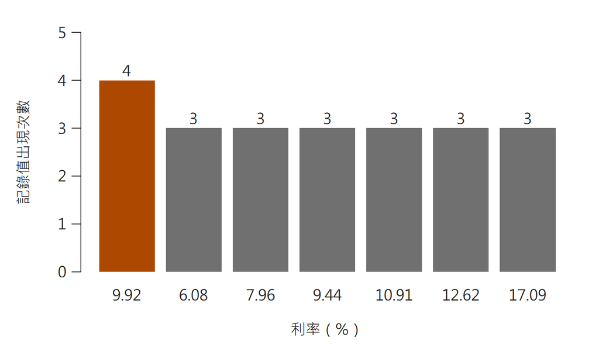

50筆貸款利率中，9.92%出現4次；圖顯示出現次數最高的七個值。

記錄值眾數是 9.92%。R 的 `mode(x)` 回傳儲存類型。

[IMS 2e](https://openintrostat.github.io/ims/explore-numerical.html) §5.2–5.5；Table 5.3；依原值重算

## 最高柱與最高密度

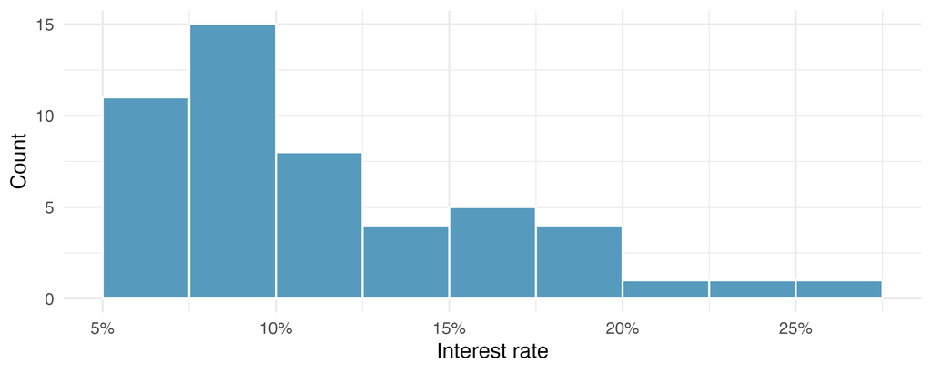

課本貸款利率直方圖，最高柱對應一段組距。

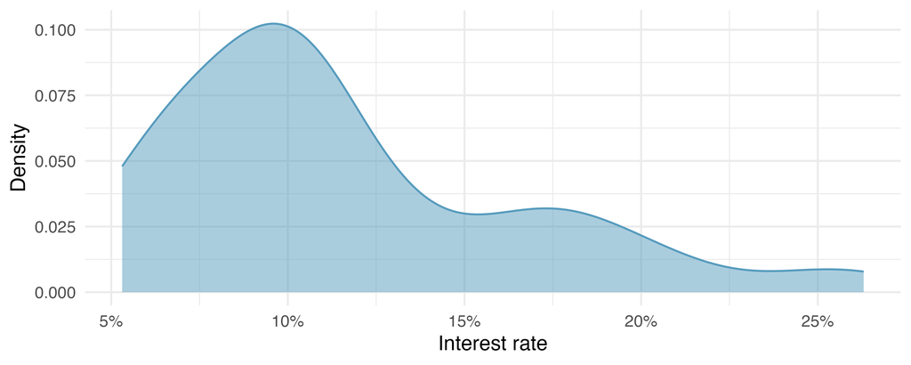

課本貸款利率平滑密度圖，峰位於密度最高處。

最高柱是一段組距；密度圖（density plot）的峰是平滑曲線的最高處。

[IMS 2e](https://openintrostat.github.io/ims/explore-numerical.html) §5.3；Figures 5.4–5.5；兩者與原始記錄值眾數不同

## 明顯的峰有幾個？

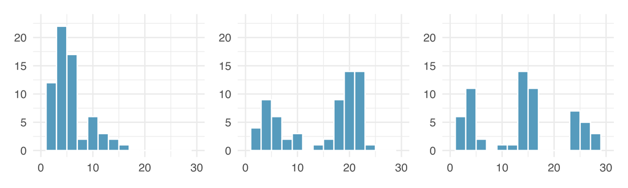

課本三張直方圖依序為單峰、雙峰、多峰，第一張的小起伏不另計為明顯峰。

單峰（unimodal）、雙峰（bimodal）、多峰（multimodal）。

[IMS 2e](https://openintrostat.github.io/ims/explore-numerical.html) §5.3；Figure 5.6

## 民調：以行政區為一筆資料

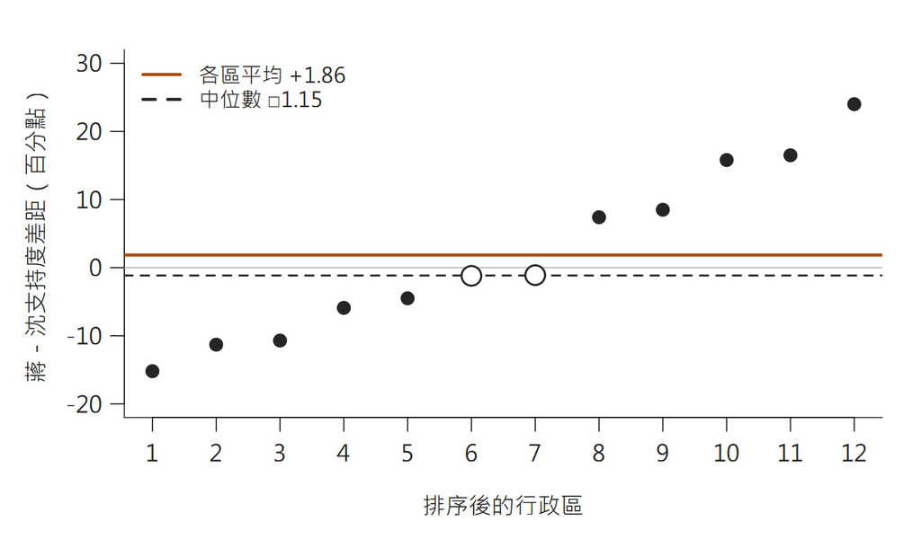

12行政區支持度差距的排序點圖，均值+1.86，中位數−1.15百分點。

平均 +1.86、中位數 −1.15 百分點（percentage point）。兩者描述不同的中心。

保存民調紀錄；依報導轉述；2026-09 歷史案例；未取得原始報告；本課程重繪

## 練習｜區的平均等於人的平均嗎？

| 摘要的單位 | 差距 |
| --- | --- |
| 12 區等權平均 | +1.86 百分點 |
| 報導全市支持度差 | +1.20 百分點 |

每個行政區在左表平均中權重相同。

各區受訪者樣本數不同。

兩個數字回答的是同一個問題嗎？

不同。區的中心不是人的全市支持度差距。12 區也不是 12 次獨立民調。

保存民調紀錄；依報導轉述；區樣本數合計1,078與總樣本1,076不同，原因未確認

## 離差：相對平均數的距離

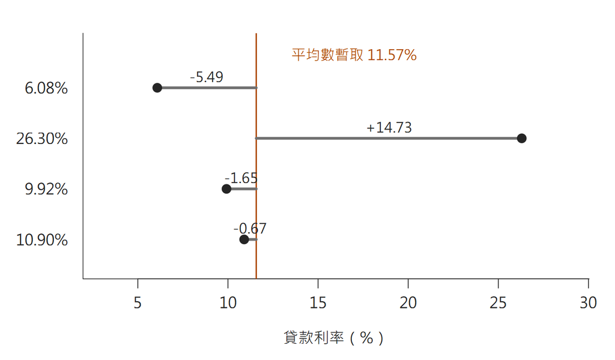

四筆貸款利率相對暫取平均11.57%的有號離差。

離散程度（dispersion）描述散布。離差（deviation）為 $x_i-\bar{x}$。

[IMS 2e](https://openintrostat.github.io/ims/explore-numerical.html) §5.4；課本四筆利率示範；全體計算須用50筆

## 離差相加會互相抵銷

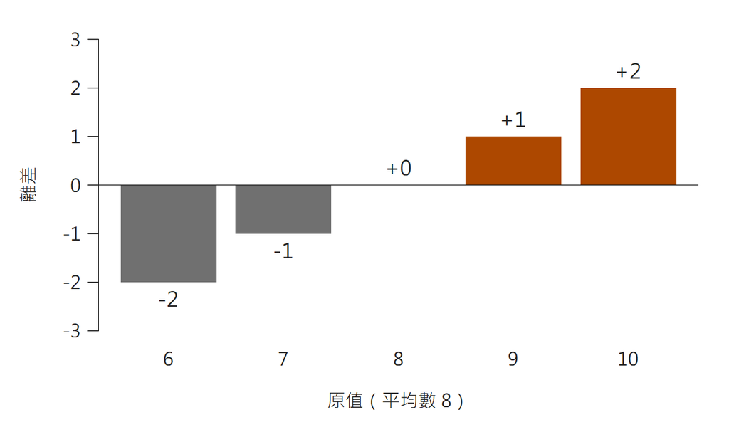

6至10的離差為−2、−1、0、1、2，加總為零。

$-2-1+0+1+2=0$，但這五個值仍有散布。

IMS §5.4；本課程自編數值示範

## 平方後，較大離差的影響增加

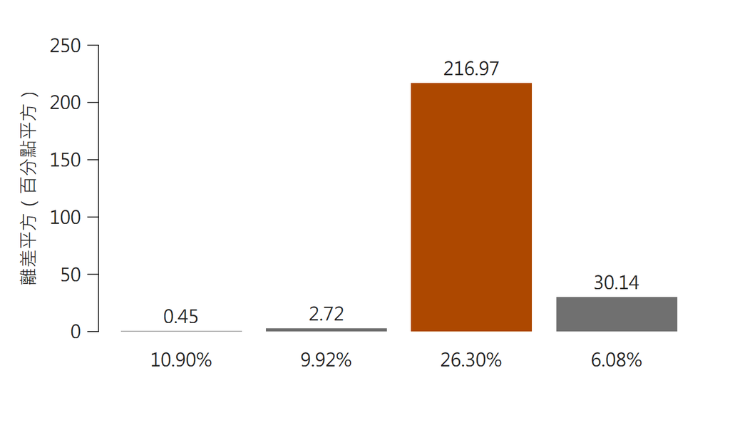

四筆貸款離差平方比較，26.3%相對11.57%的平方離差約216.97百分點平方。

變異數（variance）使用離差平方。正負都轉成非負值。

[IMS 2e](https://openintrostat.github.io/ims/explore-numerical.html) §5.4；四筆示範，非完整變異數

## 樣本與母體變異數

樣本變異數

$$s^2=\frac{\sum_{i=1}^{n}(x_i-\bar{x})^2}{n-1}$$

母體全部值的變異數

$$\sigma^2=\frac{\sum_{i=1}^{N}(x_i-\mu)^2}{N}$$

| 貸款樣本 | 數值 |
| --- | --- |
| 筆數 n | 50 |
| 分母 n−1 | 49 |
| 樣本變異數 s² | 25.52 |

變異數單位：百分點平方。

檔案內全部資料不自動等於研究母體。

[IMS 2e](https://openintrostat.github.io/ims/explore-numerical.html) §5.4；Table 5.3 全部50筆重算

## 平方和展開：兩個相同的寫法

令 $\operatorname{SS}=\sum(x_i-\bar{x})^2$，使用 $\sum x_i=n\bar{x}$：

$$\begin{aligned}
\operatorname{SS}
&=\sum x_i^2-2\bar{x}\sum x_i+n\bar{x}^2\\
&=\sum x_i^2-2n\bar{x}^2+n\bar{x}^2\\
&=\sum x_i^2-n\bar{x}^2.
\end{aligned}$$

$$s^2=\frac{\sum x_i^2-(\sum x_i)^2/n}{n-1}$$

變異數定義依 IMS §5.4；本課程平方和展開；本頁 Σ 均對 i=1,…,n 加總

## 為什麼只剩 n−1 個自由度？

自由度（degrees of freedom）：限制後能自由變動的數量。

$$d_i=x_i-\bar{x},\qquad\sum_{i=1}^{n}d_i=0$$

$$d_n=-\sum_{i=1}^{n-1}d_i$$

前 $n-1$ 個離差已知，最後一個就被決定。

貸款有 50 筆，離差自由度為 49。

本課程補充推導；自由度說明一項限制，n−1 的不偏校正接著看重複抽樣

## 估計中心，會減少平方和（1）：展開平方

大寫 $X_i$：抽樣前的隨機變項（random variable）；$\mu$：母體平均數；$\bar X$：樣本平均數。

**步驟 1** 在每個離差中，先加再減 $\bar X$：

$$X_i-\mu=(X_i-\bar X)+(\bar X-\mu)$$

**步驟 2** 兩邊平方，用 $(a+b)^2=a^2+2ab+b^2$，其中 $a=X_i-\bar X$、$b=\bar X-\mu$：

$$(X_i-\mu)^2=(X_i-\bar X)^2+2(X_i-\bar X)(\bar X-\mu)+(\bar X-\mu)^2$$

**步驟 3** 對 $i=1,\dots,n$ 逐項加總：

$$\sum(X_i-\mu)^2=\sum(X_i-\bar X)^2+\sum 2(X_i-\bar X)(\bar X-\mu)+\sum(\bar X-\mu)^2$$

本課程補充代數推導；本頁 Σ 均對 i=1,…,n 加總；不要求常態

## 估計中心，會減少平方和（2）：交叉項為零

上一頁加總後，中間項與最後一項還要化簡。

**交叉項**：$2(\bar X-\mu)$ 不含 $i$，可提到 Σ 外面。

$$\sum 2(X_i-\bar X)(\bar X-\mu)=2(\bar X-\mu)\sum(X_i-\bar X)$$

離差總和為 0：$\sum(X_i-\bar X)=\sum X_i-n\bar X=n\bar X-n\bar X=0$，所以交叉項等於 0。

**最後一項**：$(\bar X-\mu)^2$ 也不含 $i$，加 $n$ 次：

$$\sum(\bar X-\mu)^2=n(\bar X-\mu)^2$$

代回上一頁，並把 $\operatorname{SS}=\sum(X_i-\bar X)^2$ 移項：

$$\sum(X_i-\mu)^2=\operatorname{SS}+0+n(\bar X-\mu)^2\;\Longrightarrow\;\operatorname{SS}=\sum(X_i-\mu)^2-n(\bar X-\mu)^2$$

樣本平均數讓平方和更小，差額是 $n(\bar X-\mu)^2$。

本課程補充代數推導；本頁 Σ 均對 i=1,…,n 加總；不要求常態

## 重複抽樣：平均數有多大變異？（1）規則與第一步

假設 $X_1,\dots,X_n$ 獨立且同分配（independent and identically distributed），每個 $X_i$ 的變異數為 $\sigma^2$。

規則：常數倍 $\operatorname{Var}(cY)=c^2\operatorname{Var}(Y)$；獨立時可加 $\operatorname{Var}\left(\sum X_i\right)=\sum\operatorname{Var}(X_i)$。

**第 1 步** 平均數的定義：

$$\operatorname{Var}(\bar X)=\operatorname{Var}\left(\frac{1}{n}\sum_{i=1}^{n}X_i\right)$$

**第 2 步** 常數倍規則，$c=1/n$，提出時變成 $c^2=(1/n)^2=1/n^2$：

$$\operatorname{Var}(\bar X)=\frac{1}{n^2}\operatorname{Var}\left(\sum_{i=1}^{n}X_i\right)$$

本課程補充推導；接 IMS Chapter 19 p.333 的平均數 SE；非 loan50 抽樣設計查核

## 重複抽樣：平均數有多大變異？（2）代入 σ²

接上一頁：$\operatorname{Var}(\bar X)=\dfrac{1}{n^2}\operatorname{Var}\left(\sum X_i\right)$。

**第 3 步** $X_i$ 相互獨立，變異數逐項相加：

$$\operatorname{Var}(\bar X)=\frac{1}{n^2}\sum_{i=1}^{n}\operatorname{Var}(X_i)$$

**第 4 步** 每一項都是 $\operatorname{Var}(X_i)=\sigma^2$，共 $n$ 項：

$$\operatorname{Var}(\bar X)=\frac{1}{n^2}\left(\sigma^2+\cdots+\sigma^2\right)=\frac{n\sigma^2}{n^2}=\frac{\sigma^2}{n}$$

開平方，得平均數的標準誤：$\operatorname{SE}(\bar X)=\sqrt{\sigma^2/n}=\sigma/\sqrt n$。

本課程補充推導；接 IMS Chapter 19 p.333 的平均數 SE；非 loan50 抽樣設計查核

## 重複抽樣：平均數有多大變異？（3）期望值

期望值（expected value）$\operatorname{E}$ 是重複抽樣的長期平均。規則：加總的期望值等於期望值的加總，不需要獨立。每個 $X_i$ 都來自同一母體，所以 $\operatorname{E}(X_i)=\mu$。

$$\begin{aligned}
\operatorname{E}(\bar X)
&=\operatorname{E}\left(\frac{1}{n}\sum_{i=1}^{n}X_i\right) \quad\text{(a)}\\
&=\frac{1}{n}\sum_{i=1}^{n}\operatorname{E}(X_i) \quad\text{(b)}\\
&=\frac{1}{n}\left(\mu+\cdots+\mu\right)=\frac{n\mu}{n}=\mu \quad\text{(c)}
\end{aligned}$$

（a）平均數的定義 （b）常數提出，期望值逐項加總 （c）每項 $\operatorname{E}(X_i)=\mu$，共 $n$ 項

重複抽樣時，樣本平均數的長期平均等於母體平均數 $\mu$。

本課程補充推導；接 IMS Chapter 19 p.333 的平均數 SE；非 loan50 抽樣設計查核

## 除以 n−1，校正平均低估（1）：SS 的期望值

目標：算出 $\operatorname{E}(\operatorname{SS})$，其中 $\operatorname{SS}=\sum(X_i-\mu)^2-n(\bar X-\mu)^2$。對兩項各取期望值。

**第一項**：$\sigma^2$ 的定義就是 $\operatorname{E}[(X_i-\mu)^2]=\sigma^2$。

$$\operatorname{E}\left[\sum_{i=1}^{n}(X_i-\mu)^2\right]=\sum_{i=1}^{n}\operatorname{E}[(X_i-\mu)^2]=n\sigma^2$$

**第二項**：因 $\operatorname{E}(\bar X)=\mu$，$\operatorname{E}[(\bar X-\mu)^2]$ 正是 $\bar X$ 的變異數，即上一組推導的 $\sigma^2/n$。

$$\operatorname{E}\left[n(\bar X-\mu)^2\right]=n\cdot\operatorname{E}[(\bar X-\mu)^2]=n\cdot\frac{\sigma^2}{n}=\sigma^2$$

本課程補充推導；n>1、獨立同分配、有限變異數

## 除以 n−1，校正平均低估（2）：不偏

兩項相減：

$$\begin{aligned}
\operatorname{E}(\operatorname{SS})
&=\operatorname{E}\left[\sum(X_i-\mu)^2\right]-\operatorname{E}\left[n(\bar X-\mu)^2\right]\\
&=n\sigma^2-\sigma^2=(n-1)\sigma^2.
\end{aligned}$$

**除以 $n$**：平均而言偏低。

$$\operatorname{E}\left(\frac{\operatorname{SS}}{n}\right)=\frac{(n-1)\sigma^2}{n}<\sigma^2$$

**除以 $n-1$**：剛好校正。

$$\operatorname{E}(s^2)=\operatorname{E}\left(\frac{\operatorname{SS}}{n-1}\right)=\frac{(n-1)\sigma^2}{n-1}=\sigma^2$$

不偏估計（unbiased estimation）不保證單次樣本估得正確。

本課程補充推導；n>1、獨立同分配、有限變異數；不偏的是 s²，不是開平方後的 s

## SD：回到原本的單位

標準差（standard deviation，SD）

$$s=\sqrt{s^2}$$

$$\sqrt{25.52}\approx5.05$$

SD 描述個別貸款利率的散布。

| 量 | 單位 |
| --- | --- |
| 利率 | % |
| 利率差、SD | 百分點 |
| 變異數 | 百分點平方 |

```r
var(x)
sd(x)
```

[IMS 2e](https://openintrostat.github.io/ims/explore-numerical.html) §5.4；全體50筆重算

## 平均數正負一個 SD

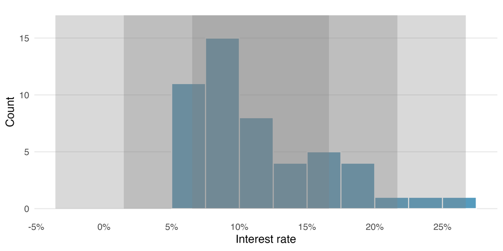

課本貸款利率圖標示平均數正負一個與兩個SD的範圍，範圍描述此資料。

這是個別值的散布。平均數 ± SD 不能直接當作平均數的信賴區間（confidence interval）。

[IMS 2e](https://openintrostat.github.io/ims/explore-numerical.html) §5.4；未編號SD範圍圖（本機PDF Figure 5.7）

## 相同平均數與 SD，形狀仍不同

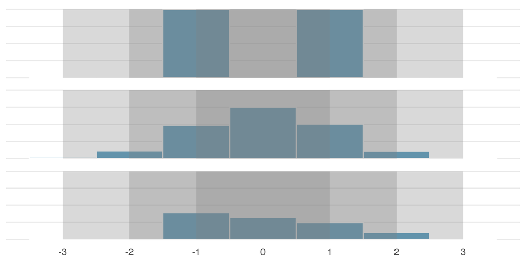

課本三種分布均值0、SD1，但形狀不同。

68%／95% 規則需近似常態形狀，不能套到所有分布。

[IMS 2e](https://openintrostat.github.io/ims/explore-numerical.html) §5.4；Figure 5.7（本機PDF Figure 5.8）

## Slido｜Part 2

[**點此開啟 Slido 作答頁 ↗**](https://app.sli.do/event/9DzgBhTDhyRJFR5V1faviF) · 活動代碼 **2612995**

[figure not shown]

[Week04 Slido 活動入口](https://app.sli.do/event/9DzgBhTDhyRJFR5V1faviF)；沿用既有活動